# A5: Incarceration

Jonathan Cao

### Introduction

Incarceration in the United States is continuously rising at unprecedented levels, with our coutry having the highest incarceration rate globally. Racial disparities are a significant reason for this issue, particularly affecting Black Americans who are incarcerated at much higher percentages than any other race, while being a minority of the country. I will focus on the prison and jail populations over time For this analysis, figuring out the variables that affect race and gender in incarceration. The variables chosen for include the incarceration rates per 100,000 people for different racial groups and genders, as well as the total incarceration rates for different states and counties provided from the Vera institute. These variables will help illustrate the systemic racism and gender disparities in the U.S. criminal justice system.

### Summary Information

- The average incarceration rate across all counties in the most recent year available is 610.73 per 100,000 people.
- The highest incarceration rate is found in King County, with a rate of 26654.55 per 100,000 people.
- The lowest incarceration rate is found in Caldwell County, with a rate of 0.00 per 100,000 people.
- Over the last 28 years, the incarceration rate for Black Americans has changed by -37.65%.
- The gender disparity is evident, with men being incarcerated at a rate 6.25 times higher than women.

The variables demonstrate how Black American incarceration has actually decreased from 1990 to 2018. However, it does not remove the fact that Black Americans are still incarcerated at a much higher rate, and how there must be more targeted reforms, seeing how much more men are incarcerated as well.

### The Dataset

- The data for this analysis was collected by the Vera Institute of Justice–non-profit organization focused on criminal justice reform.
- The data was collected by the U.S. Department of Justice Bureau of Justice Statistics (BJS), supplemented with data from state department correction facilities when the federal data is not available. I generated the data utilizing Rmarkdown code, to simplify the necessary variable and calculations seen above.
- The data was collected to provide a comprehensive overview of the incarceration rates in the United States, including the total prison population, jail population, and demographic breakdown, including race and gender.
- The dataset contains approximately 160,000 rows.
- The dataset contains 20 columns including variables such as the year, state, county, total prison population, jail population, and demographic breakdown, and more miscellaneous variables such as the total jail population rate, total prison population rate, and the total incarceration rate.
- When working with this data, ethical considerations must be taken into account, particularly when analyzing the race and gender disparities in the U.S. justice systems of the data. It is important to consider the power dynamics and the potential for reinforcing stereotypes or biases in the data analysis.

The data is collected by the U.S. Department of Justice Bureau of Justice Statistics, supplemented with data from state department correction facilities when the federal data is not available. This pushes certain limitations, as this means that the data is collected by the government, which may induce biases that they might hide to the public. For example, the data may not be collected consistently across all states, or there may be discrepancies in how the data is collected or reported, so that the country seems more “just” than it really is. Additionally, with so many factors in play and discrepancies, it is inevitable that the data will have its inaccuracies and inconsistencies in the data, which could affect the results of the analysis. The data may not capture all aspects of the criminal justice system, such as the impact of policing practices or sentencing policies. Those issues are widespread within our country, and may provide biased results to such datasets as they play a factor in incarcerating victims. This could limit the scope of the analysis and prevent a comprehensive understanding of the issues at hand. The data may also not capture the full extent of racial disparities in the criminal justice system, as it may not include data on other marginalized groups, as well as the gender disparities in the criminal justice system. This could limit the ability to identify and address the root causes of these disparities and develop effective solutions.

### Trends Over Time Chart

The following chart shows the trend of incarceration rates over time for Black and White Americans. It illustrates the significant racial disparities in incarceration rates and how these have evolved over the years, whether for the better or worse.

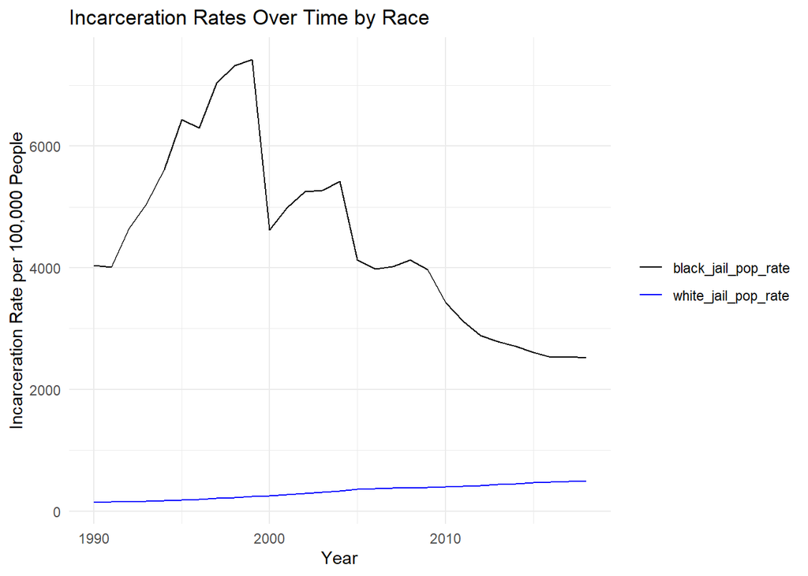

- The chart clearly shows the Incarceration Rates per 100,000 people
- The chart shows the trend of incarceration rates over time for Black and White Americans
- Despite the incarceration rates for black Americans decreasing over time, it is still significantly higher than that of white Americans

### Variable Comparison Chart

This chart shows the gender disparities within incarceration rates, for males and females across different states.

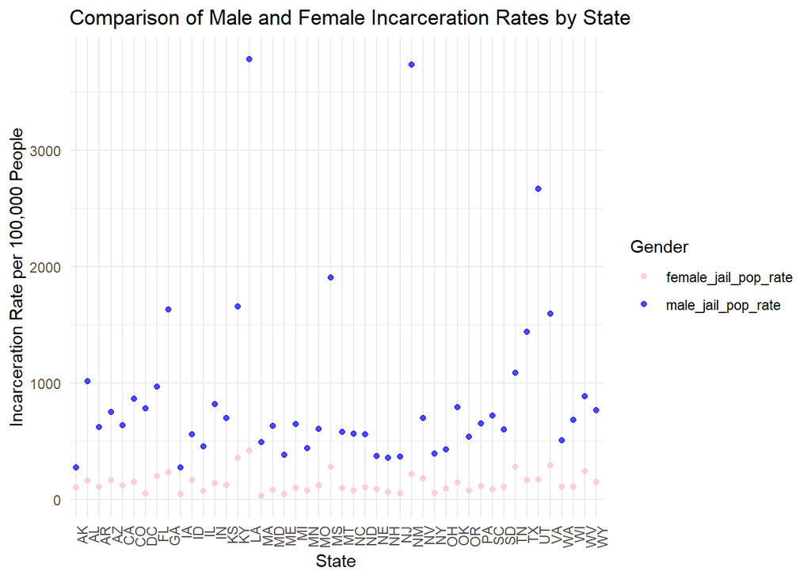

- The chart shows the Incarceration Rates per 100,000 people.
- The chart clearly identifies that much more males are incarcerated than females.

### Map

[figure not shown]